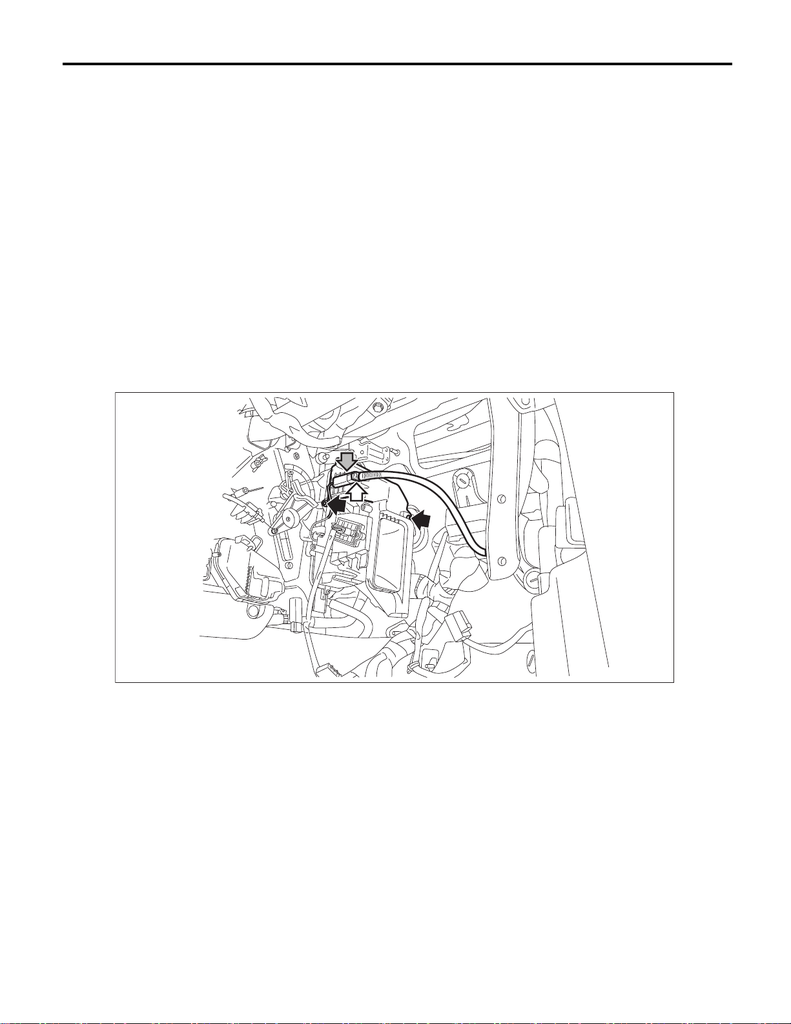

AC-57

Evaporator

HVAC SYSTEM (HEATER, VENTILATOR AND A/C)

17.Evaporator

A: REMOVAL

1) Disconnect the ground cable from battery. <Ref. to NT-5, BATTERY, NOTE, Note.>

NOTE:

For models other than STI model, disconnect the ground terminal from battery sensor.

2) Using the refrigerant recovery system, discharge refrigerant. <Ref. to AC-26, PROCEDURE, Refrigerant

Recovery Procedure.>

3) Remove the intercooler.

• Except for STI model: <Ref. to IN(w/o STI)-38, REMOVAL, Intercooler.>

• STI model: <Ref. to IN(STI)-13, REMOVAL, Intercooler.>

4) Remove the expansion valve - cooling. <Ref. to AC-61, REMOVAL, Expansion Valve.>

5) Remove the glove box. <Ref. to EI-63, REMOVAL, Glove Box.>

6) Remove the engine control module (ECM). (STI model) <Ref. to FU(STI)-56, REMOVAL, Engine Control

Module (ECM).>

7) Remove the blower motor unit assembly. <Ref. to AC-35, REMOVAL, Blower Motor Unit Assembly.>

8) Remove the evaporator assembly - cooling.

(1) Disconnect the connector and lock of the thermostat - cooling.

(2) Remove the screws and detach the cover.

AC-02701

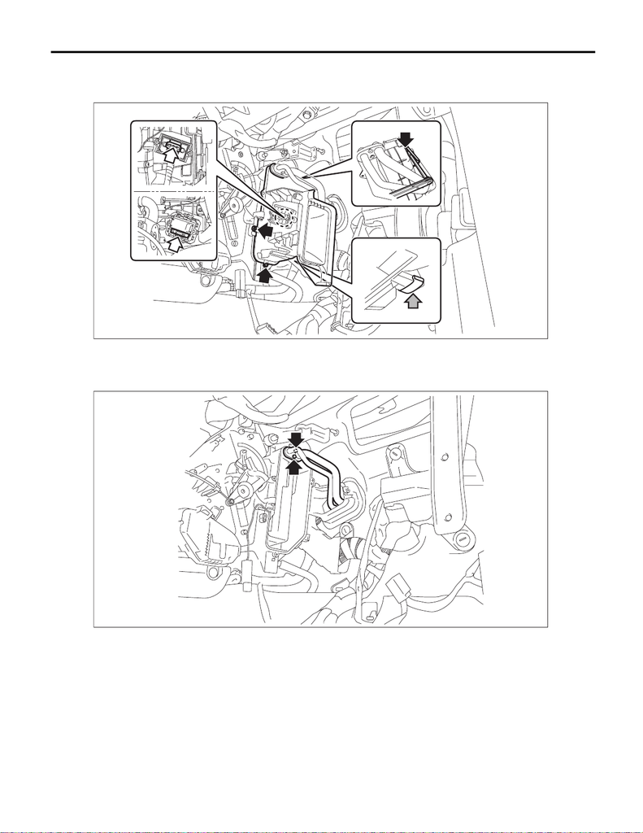

AC-58

Evaporator

HVAC SYSTEM (HEATER, VENTILATOR AND A/C)

(3) Remove the cover - heater unit.

1. Disconnect the power transistor connector.

2. Remove the screws and clips to remove the cover - heater unit.

(4) Remove the bolt, and detach the pipe - evaporator core.

Preparation tool:

Hexagon wrench: 4 mm (0.16 in)

AC-02702

AC-02703

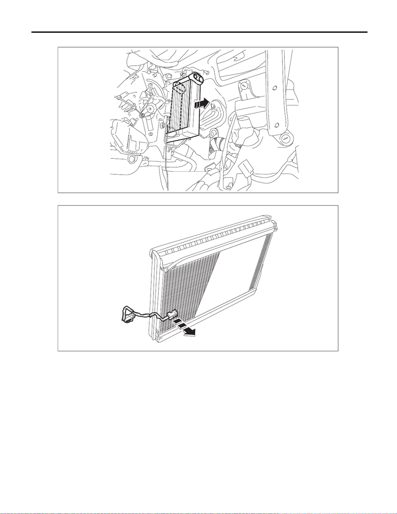

AC-59

Evaporator

HVAC SYSTEM (HEATER, VENTILATOR AND A/C)

(5) Remove the evaporator assembly - cooling.

(6) Remove the thermostat - cooling.

AC-02704

AC-02705

[figure not shown]

AC-60

Evaporator

HVAC SYSTEM (HEATER, VENTILATOR AND A/C)

B: INSTALLATION

CAUTION:

• If the evaporator assembly - cooling has been replaced, add an appropriate amount of compressor

oil. <Ref. to AC-34, ADJUSTMENT, Compressor Oil.>

• When the evaporator assembly - cooling has been replaced, replace the packing of the expansion

valve - cooling with a new one, and then apply compressor oil.

• Make sure that the water seal packing on the cover attachment area is securely attached.

• Replace the O-rings with new parts, and then apply compressor oil.

• After installing the grille assembly - ventilation RH, check that the air vent grille of the grille assem-

bly - ventilation RH is inserted correctly into the air vent duct.

1) Install the thermostat - cooling. <Ref. to AC-81, INSTALLATION, Evaporator Sensor.>

2) Install the evaporator assembly - cooling.

3) Install the blower motor unit assembly.

Tightening torque:

7.5 N·m (0.8 kgf-m, 5.5 ft-lb)

4) Install the engine control module (ECM). (STI model) <Ref. to FU(STI)-56, INSTALLATION, Engine Con-

trol Module (ECM).>

5) Install the glove box.

6) Install the expansion valve. <Ref. to AC-62, INSTALLATION, Expansion Valve.>

7) Install the intercooler.

• Except for STI model: <Ref. to IN(w/o STI)-41, INSTALLATION, Intercooler.>

• STI model: <Ref. to IN(STI)-14, INSTALLATION, Intercooler.>

8) Connect the battery ground terminal. <Ref. to NT-5, BATTERY, NOTE, Note.>

NOTE:

For models other than STI model, connect the ground terminal to battery sensor.

9) Charge refrigerant. <Ref. to AC-27, PROCEDURE, Refrigerant Charging Procedure.>

C: INSPECTION

1) Check the evaporator fin for dust. Blow with compressed air or flush fins with water as needed.

2) If any oil leak is found, replace the evaporator assembly - cooling.